# Regression and model validation

The theme of the second week was regression and model validation.

As a prelude for this week main theme there were some data pretreatment. More about that can be seen from other file. Main idea in the pretreatment was that we recuded the amount of the variables by creating sum variables.

## Preparation and overview

The data that is used is a survey data from 2014 and 2015. It cover many variables about teaching and learning.

First task is to take a quick look of the data. First three commands gives us basic information from data. The fourth one is in two parts. First we give instructions for plotting. After that we can easily do the plot. There is also some background variables.

```r
head(learndata)
```

```
##   X gender age attitude  deep  stra     surf points
## 1 1      F  53       37 3.750 3.375 2.583333     25
## 2 2      M  55       31 2.875 2.750 3.166667     12
## 3 3      F  49       25 3.875 3.625 2.250000     24
## 4 4      M  53       35 3.500 3.125 2.250000     10
## 5 5      M  49       37 3.750 3.625 2.833333     22
## 6 6      F  38       38 4.875 3.625 2.416667     21
```

```r
str(learndata)
```

```
## 'data.frame':    166 obs. of  8 variables:
##  $ X       : int  1 2 3 4 5 6 7 8 9 10 ...
##  $ gender  : Factor w/ 2 levels "F","M": 1 2 1 2 2 1 2 1 2 1 ...
##  $ age     : int  53 55 49 53 49 38 50 37 37 42 ...
##  $ attitude: int  37 31 25 35 37 38 35 29 38 21 ...
##  $ deep    : num  3.75 2.88 3.88 3.5 3.75 ...
##  $ stra    : num  3.38 2.75 3.62 3.12 3.62 ...
##  $ surf    : num  2.58 3.17 2.25 2.25 2.83 ...
##  $ points  : int  25 12 24 10 22 21 21 31 24 26 ...
```

```r
summary(learndata)
```

```
##        X          gender       age           attitude          deep
##  Min.   :  1.00   F:110   Min.   :17.00   Min.   :14.00   Min.   :1.625
##  1st Qu.: 42.25   M: 56   1st Qu.:21.00   1st Qu.:26.00   1st Qu.:3.500
##  Median : 83.50           Median :22.00   Median :32.00   Median :3.875
##  Mean   : 83.50           Mean   :25.51   Mean   :31.43   Mean   :3.796
##  3rd Qu.:124.75           3rd Qu.:27.00   3rd Qu.:37.00   3rd Qu.:4.250
##  Max.   :166.00           Max.   :55.00   Max.   :50.00   Max.   :4.875
##       stra            surf           points
##  Min.   :1.250   Min.   :1.583   Min.   : 7.00
##  1st Qu.:2.625   1st Qu.:2.417   1st Qu.:19.00
##  Median :3.188   Median :2.833   Median :23.00
##  Mean   :3.121   Mean   :2.787   Mean   :22.72
##  3rd Qu.:3.625   3rd Qu.:3.167   3rd Qu.:27.75
##  Max.   :5.000   Max.   :4.333   Max.   :33.00
```

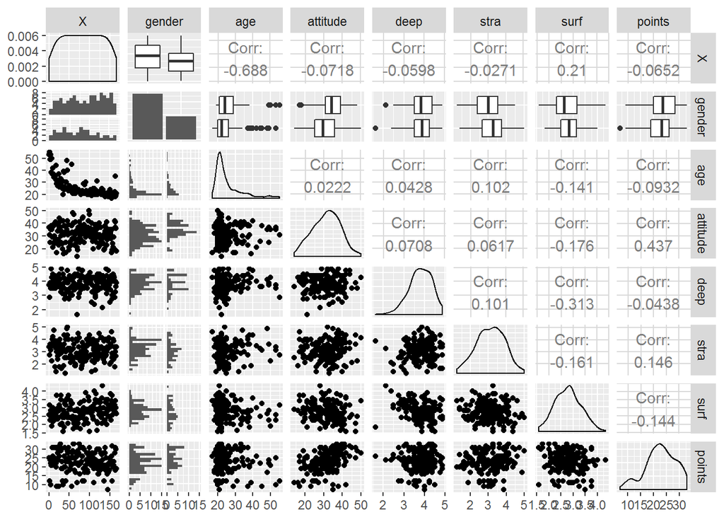

```r
summaryGraphs <- ggpairs(learndata, lower = list(combo = wrap("facethist", bins = 20)))
summaryGraphs
```

From the graphical summary can be seen more information. It seems that there is some differences in the means between genders, but they are not big enough to be statistically significant. There is some differences in the scatter plots. We will use correlations more later.

## Regression model

The next task is to do regression model for exam points (variable points). For that we will use three explanatory variable. It seems that the best candidates are attitude, stra and surf. Variables age and deep have lower correlation coefficient than the picked three variables. Attitude refers attitude toward statistics, stra strategic and surd surface approach.

We can do the model easly with function lm.

```r
learnModel <- lm(points ~ attitude + stra + surf, data = learndata)
summary(learnModel)
```

```
##
## Call:
## lm(formula = points ~ attitude + stra + surf, data = learndata)
##
## Residuals:
##      Min       1Q   Median       3Q      Max
## -17.1550  -3.4346   0.5156   3.6401  10.8952
##
## Coefficients:
##             Estimate Std. Error t value Pr(>|t|)
## (Intercept) 11.01711    3.68375   2.991  0.00322 **
## attitude     0.33952    0.05741   5.913 1.93e-08 ***
## stra         0.85313    0.54159   1.575  0.11716
## surf        -0.58607    0.80138  -0.731  0.46563
## ---
## Signif. codes:  0 '***' 0.001 '**' 0.01 '*' 0.05 '.' 0.1 ' ' 1
##
## Residual standard error: 5.296 on 162 degrees of freedom
## Multiple R-squared:  0.2074, Adjusted R-squared:  0.1927
## F-statistic: 14.13 on 3 and 162 DF,  p-value: 3.156e-08
```

The regression model has three parts.

$$y = \alpha + \beta x + \epsilon$$
Where alpha refers to the constant part, where our model intercepts the y-axis. Beta and x refers to our explanatory variables and epsilon is the residual.

In the summary table (Intercept) refers to alpha-part. For attitude, stra and surf there is estimates for beta-parts. Absolute values of their estimates are less than one. Standard error of the attitude is much more smaller than with stra and surf.

Before interpreting p-values, there is a null hypothesis for all three explanatory variables. The null hypothesis is that their estimates for beta is zero. For the testig of the null hypothesis there is t-test. Only for attitude the p-value is small enough for rejecting null hypothesis. With stra and surf there is not enough evindence for the rejection. So we can do a new regression model with one explanatory variable attitude.

```r
learnModel2 <- lm(points ~ attitude, data = learndata)
summary(learnModel2)
```

```
##
## Call:
## lm(formula = points ~ attitude, data = learndata)
##
## Residuals:
##      Min       1Q   Median       3Q      Max
## -16.9763  -3.2119   0.4339   4.1534  10.6645
##
## Coefficients:
##             Estimate Std. Error t value Pr(>|t|)
## (Intercept) 11.63715    1.83035   6.358 1.95e-09 ***
## attitude     0.35255    0.05674   6.214 4.12e-09 ***
## ---
## Signif. codes:  0 '***' 0.001 '**' 0.01 '*' 0.05 '.' 0.1 ' ' 1
##
## Residual standard error: 5.32 on 164 degrees of freedom
## Multiple R-squared:  0.1906, Adjusted R-squared:  0.1856
## F-statistic: 38.61 on 1 and 164 DF,  p-value: 4.119e-09
```

The easiest way to explain the regression model is do scatter plot that has a regression line.

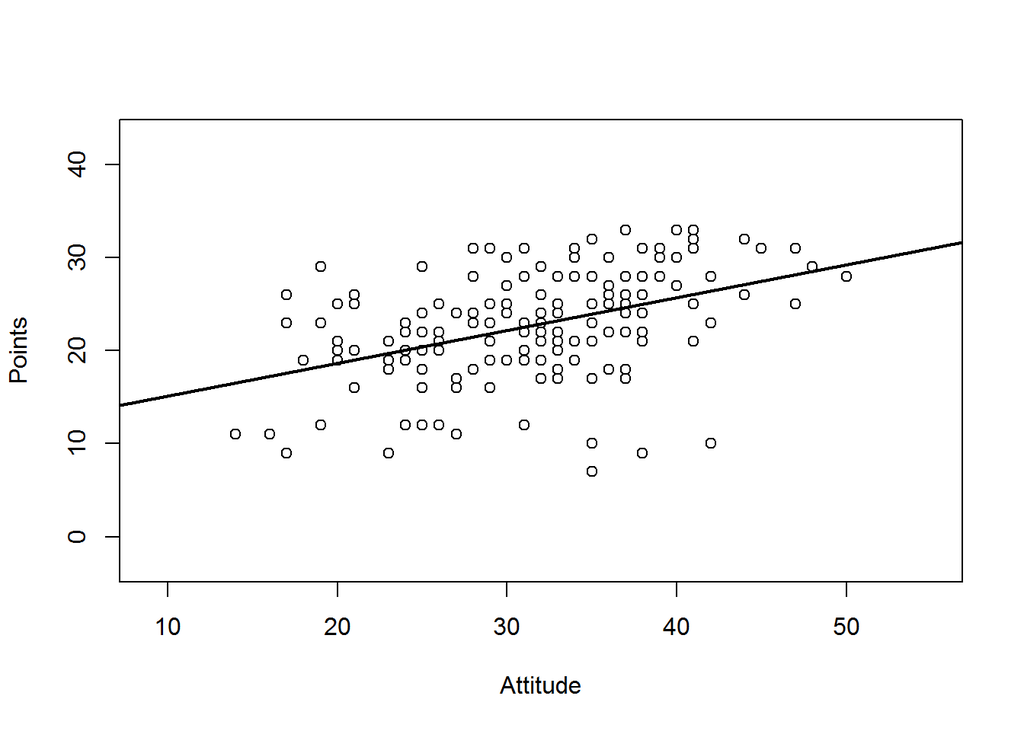

So when attitude increases by one then points increases by 0.35 (beta estimate). The regression line is fitted so that the sum of the squares of the residuals (distances from observations to the line) is minimized. Beta is the slope of the line.